# Gender differences in gene expression in Melanoma: an analysis of the TCGA Melanoma database

Author

Kiera Patton, contributors to broader project: Dan Deegan, Gillian Mcguire, Nora Engel

Published

May 3, 2024

## Aims

Melanoma is one of the deadliest forms of skin cancer, with high mortality despite being fairly rare, and differences in mortality based on patient gender. (Dakup, Greer, and Gaddameedhi 2022) The exact biological or environmental reasons for this are still being pinned down. Some of the possible explanations include immunological and mutational burden differences. (Klein and Flanagan 2016) The goal of this project is to discover highly expressed genes that are differentially expressed between genders in melanoma, using publicly available bioinformatics databases such as The Cancer Genome Atlas. I will use R packages such as Deseq2 and cytoscape that allow you to query gene expression differences between subsets of data and look at differences in biological pathways associated with those genes, with the idea being to construct maps of the pathways involved ideally.

## Scope and System

The scope of this project was mainly genomic information from large bioinformatic databases like NCBI’s The Cancer Genome Atlas. This was supplemented by geographic data as well.

## Results

### Map of differences in melanoma mortality by gender by region

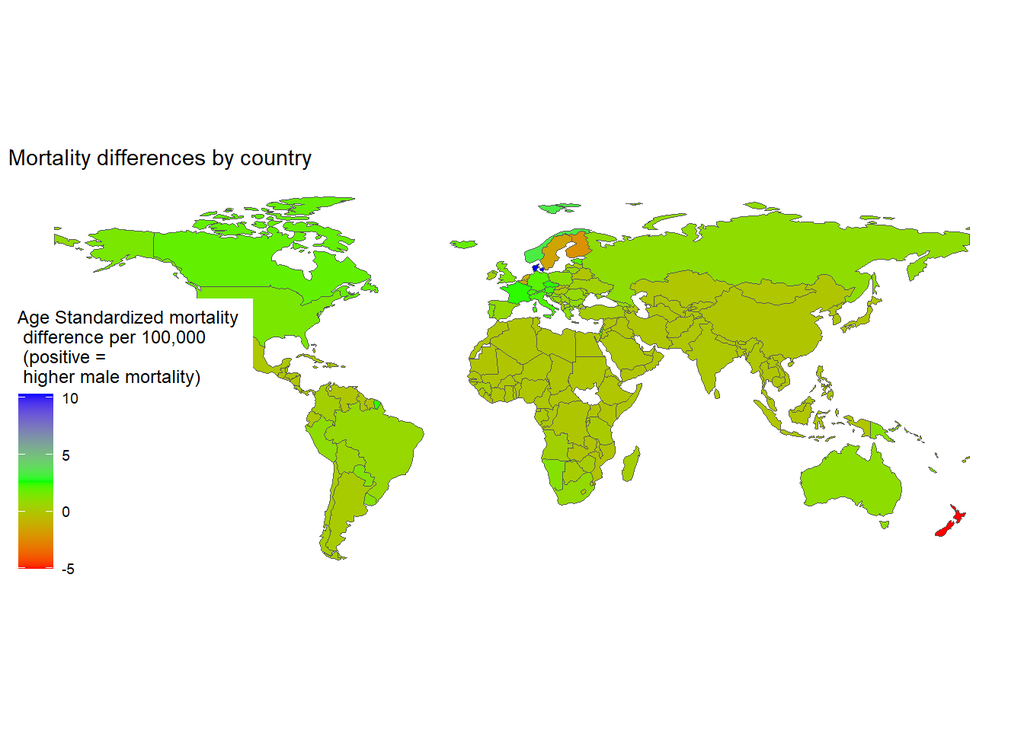

There were significant differences in whether melanoma was male or female biased in terms of mortality throughout the world, with most of the Global North having slightly higher male mortality. New Zealand, Finland, and Denmark were outliers to this trend.

### Heatmaps and pathway analysis of TCGA Data

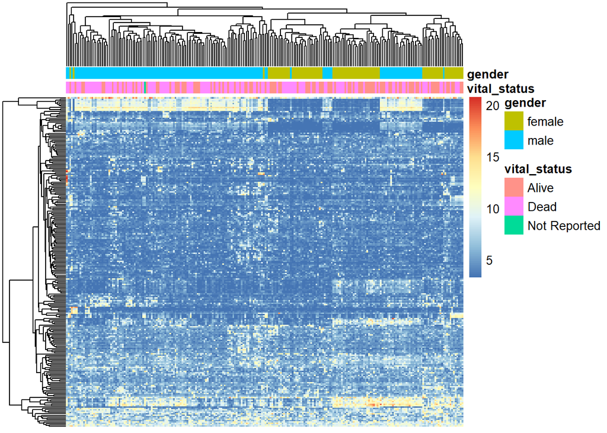

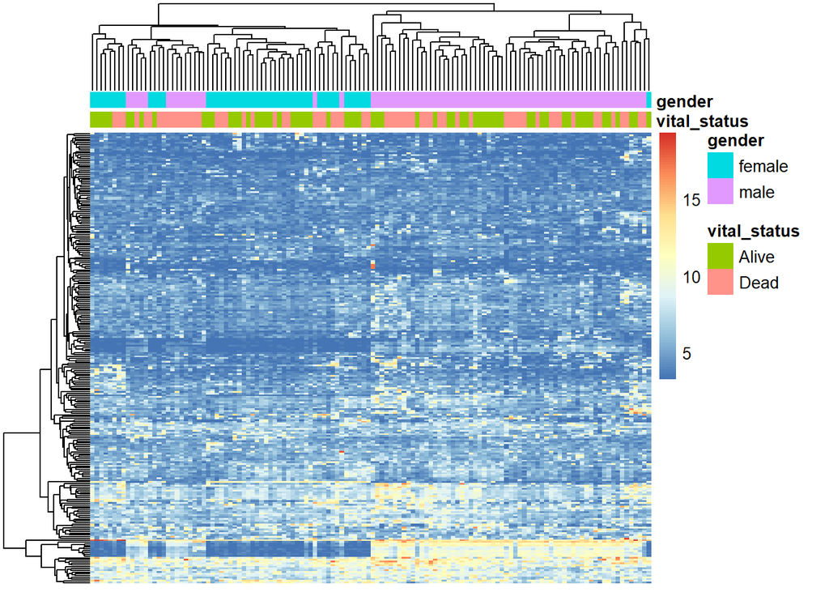

Y linked transcription factors are already clearly visible in the heatmap, with female samples having no expression and male samples having high levels of expression of these transcription factors.

### Volcano plot of differential gene expression

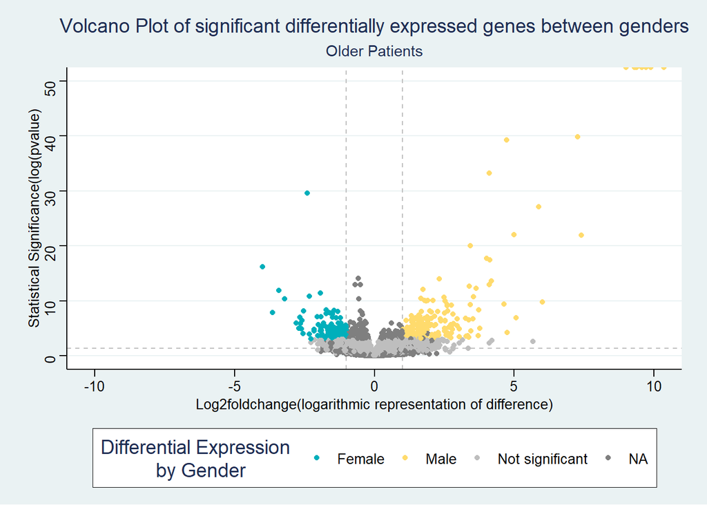

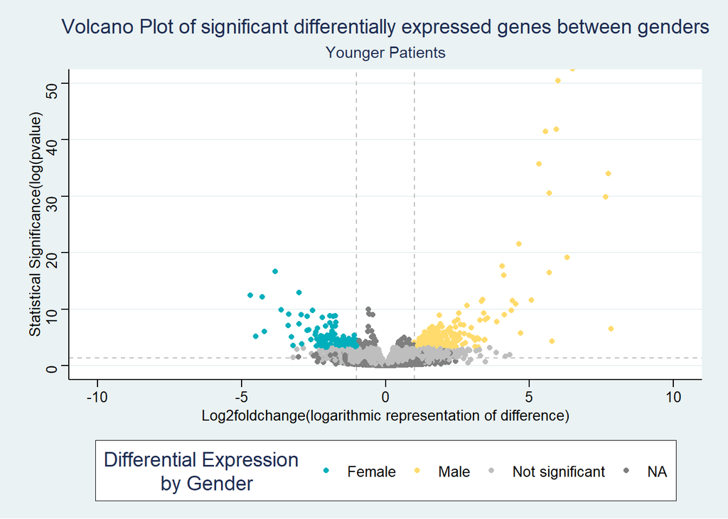

```
[1] "Older Patients"
```

```
# A tibble: 2 × 2
  diffexpressed     n
  <chr>         <int>
1 Male            140
2 Female          102
```

```
[1] "Younger Patients"
```

```
# A tibble: 2 × 2
  diffexpressed     n
  <chr>         <int>
1 Male            171
2 Female           84
```

In both young and old samples, males had a significantly larger number of differentially expressed genes, which may reflect the increased mutational load seen in tumors in males or be a marker of disease severity that leads to mortality differences.

### Analysis of differentially expressed genes in Biological Pathways

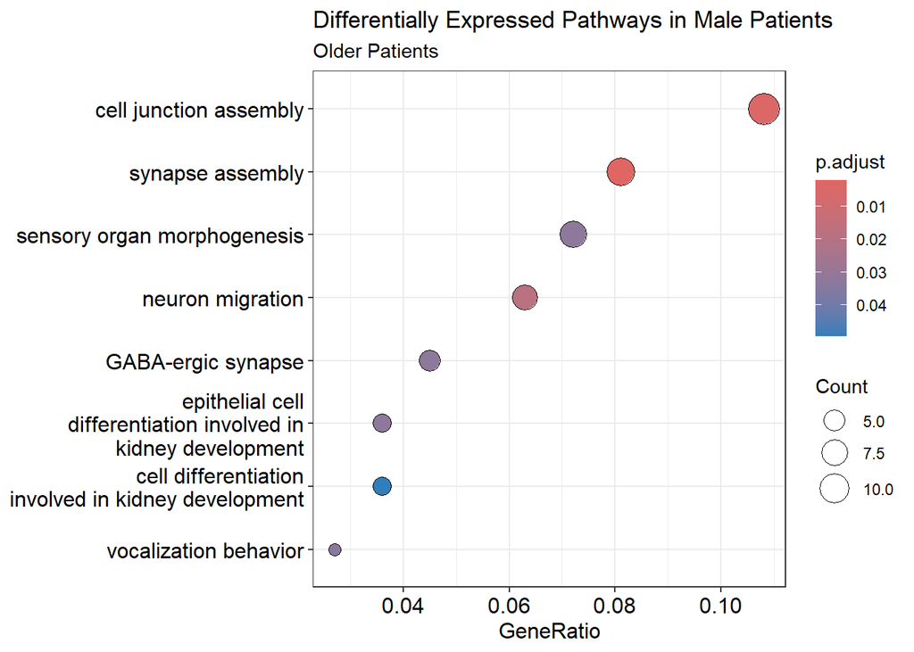

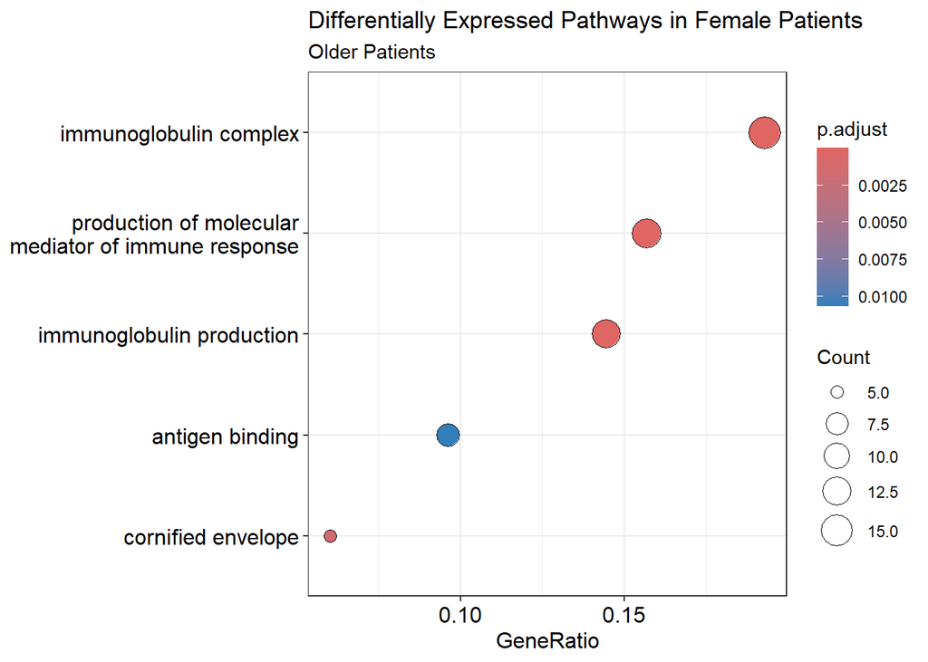

In older patients, pathways related to immune response were enriched in female patient samples. Genes on pathways related to the immunoglobin complex were a full 20% of differentially expressed genes. Pathways relating to cell differentiation and neural activity were enriched in older male patient samples, perhaps reflecting the developmental history of melanocytes from the neural crest.

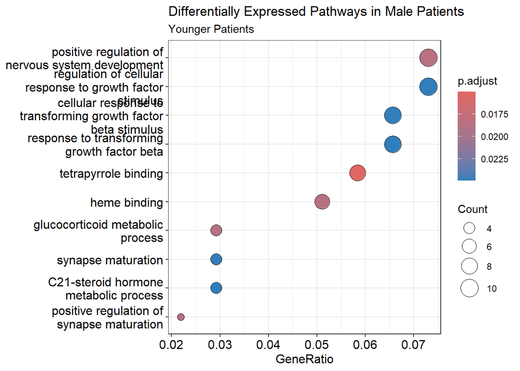

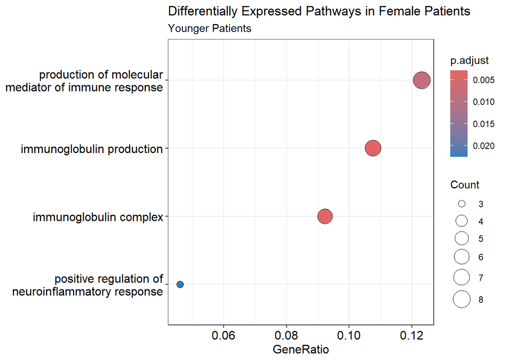

In younger patients, similar trends held true, with 13% of the differentially expressed genes in female patients being involved with immune mediation, and 9% again being part of the immunoglobin complex pathway.

[figure not shown]

[figure not shown]

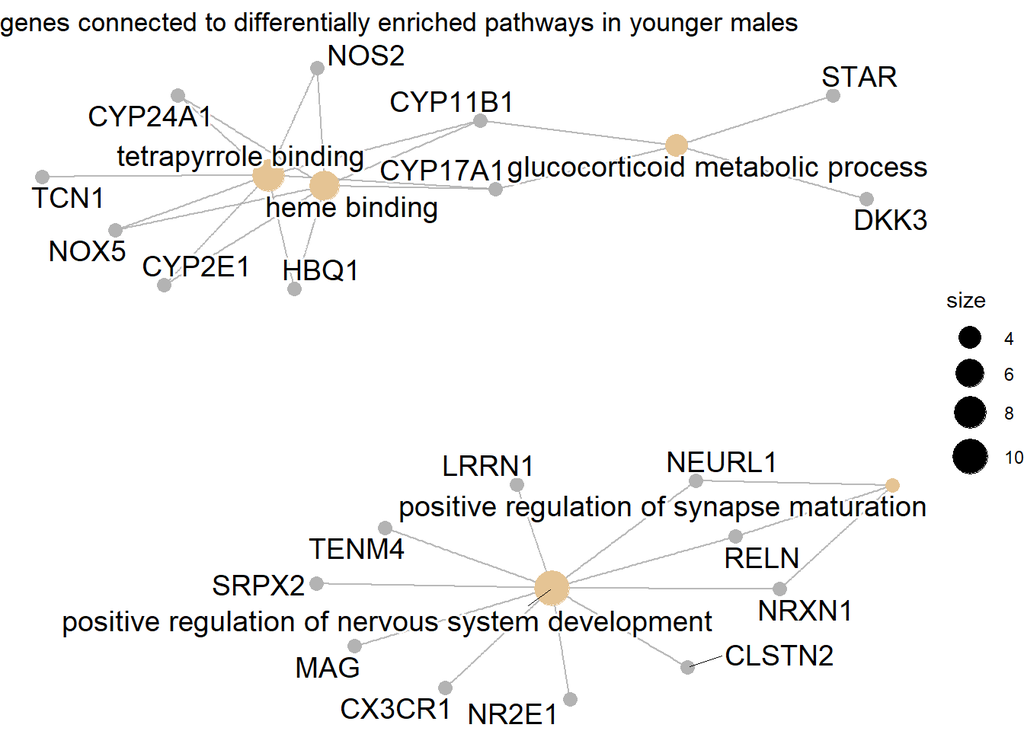

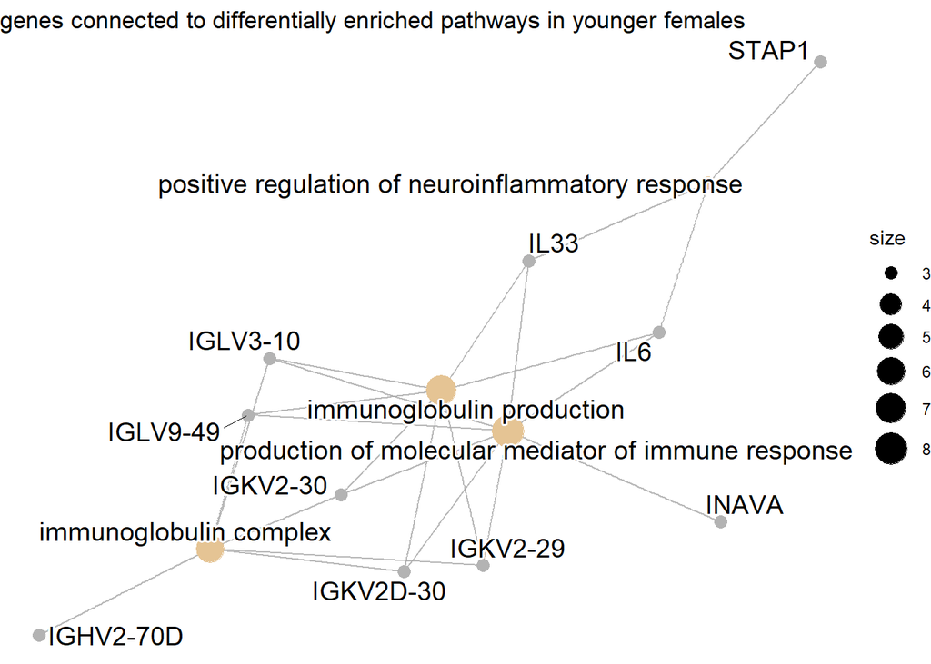

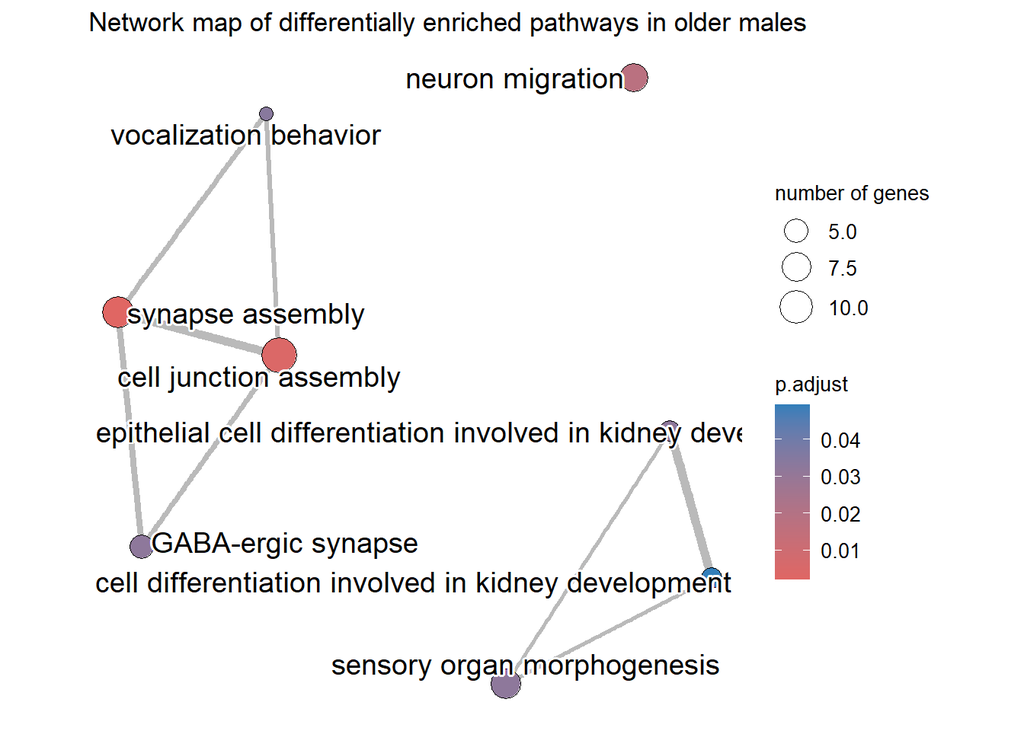

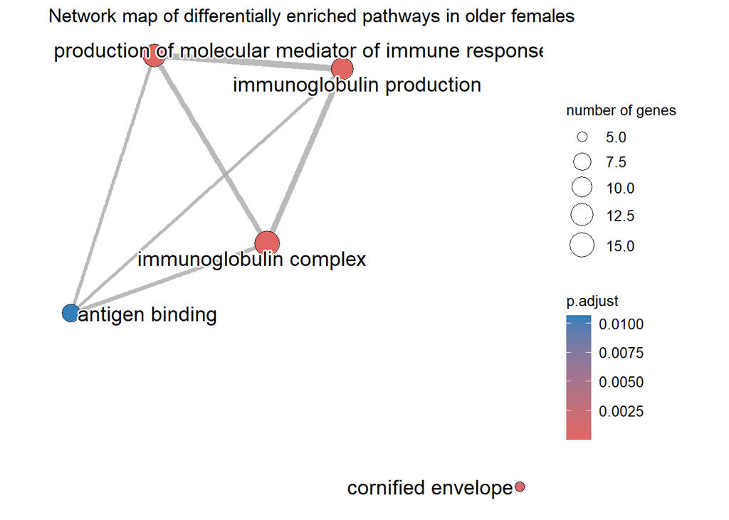

## Conclusions

Distinct transcriptional networks in melanoma are enriched in male versus female patients which may help to provide a biological explanation for differences in mortality from melanoma. Particularly, samples from female patients in both age groups are significantly more likely to have highly expressed genes related to immune function. These differences may be relevant to future clinical treatments. A future direction may be to treat gender as a continuous variable based on a paper about bayesian nearest neighbors.(Rubin and Yang 2023)

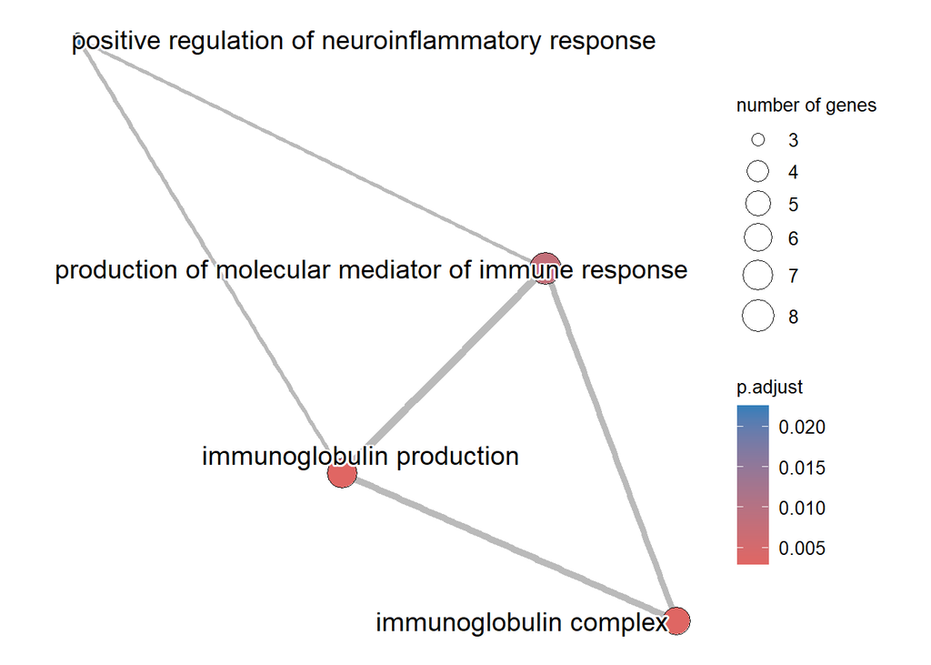

[figure not shown]

## References

Colaprico, Antonio, Tiago C. Silva, Catharina Olsen, Luciano Garofano, Claudia Cava, Davide Garolini, Thais S. Sabedot, et al. 2016. “TCGAbiolinks: An R/Bioconductor Package for Integrative Analysis of TCGA Data.” *Nucleic Acids Research* 44 (8): e71–71. https://doi.org/10.1093/nar/gkv1507.

Dakup, Panshak P., Adam J. Greer, and Shobhan Gaddameedhi. 2022. “Let’s Talk about Sex: A Biological Variable in Immune Response Against Melanoma.” *Pigment Cell & Melanoma Research* 35 (2): 268–79. https://doi.org/10.1111/pcmr.13028.

“International Agency for Research on Cancer.” 2020, February. https://doi.org/10.32388/pfg7jq.

Klein, Sabra L., and Katie L. Flanagan. 2016. “Sex Differences in Immune Responses.” *Nature Reviews Immunology* 16 (10): 626–38. https://doi.org/10.1038/nri.2016.90.

Rubin, Joshua, and Wei Yang. 2023. “Accounting for Sex Differences as a Continuous Variable in Cancer Treatments.” http://dx.doi.org/10.21203/rs.3.rs-3120372/v1.